# What the Residuals Row Really Means in the R Linear-Regression Summary

```r
pacman::p_load(tidyverse, openintro, knitr)
```

# 1. The dataset: 8 pre-term births

We use the same `openintro::births14` subset we’ve been building the other lessons on — pre-term babies only, weight converted to kilograms, the last 8 rows of the filtered table:

```r
preemie_data <- openintro::births14 %>%
  filter(premie == "premie") %>%
  mutate(weight_kg = weight * 0.453592) %>%
  slice_tail(n = 8) %>%
  select(weeks, weight_kg) %>%
  arrange(weeks, weight_kg) %>%          # renumber so #1 is bottom-left, #8 is top-right
  mutate(row_id = row_number(), .before = 1)

preemie_data
```

| row_id | weeks | weight_kg |
| --- | --- | --- |
| 1 | 32 | 1.057 |
| 2 | 32 | 1.651 |
| 3 | 33 | 2.177 |
| 4 | 34 | 3.062 |
| 5 | 35 | 2.531 |
| 6 | 36 | 2.640 |
| 7 | 36 | 2.667 |
| 8 | 36 | 3.828 |

The research question is the same one we’ve had throughout:

> **Given gestational age in weeks, what birth weight should we expect?**

> We measure gestational age precisely from early ultrasound, but the baby’s weight before delivery is unknown. A regression line turns the first (easy, already known) into an estimate of the second (hard, not yet known).

Before we do anything else, we assign each observation a stable **row id** and a matching **colour**. Observations are ordered by `weeks` ascending, then by `weight_kg` ascending — so on the scatterplot, baby #1 sits at the bottom-left and baby #8 at the top-right. The colour travels with that baby through every subsequent table and plot; only the first scatterplot will label the numbers explicitly, since from then on the colour alone is enough to track an observation.

```r
row_colors <- c(
  "1" = "#E41A1C",  # red
  "2" = "#377EB8",  # blue
  "3" = "#4DAF4A",  # green
  "4" = "#984EA3",  # purple
  "5" = "#FF7F00",  # orange
  "6" = "#F781BF",  # pink
  "7" = "#A65628",  # brown
  "8" = "#111111"   # near-black
)

preemie_data %>%
  mutate(color = row_colors[as.character(row_id)]) %>%
  knitr::kable(caption = "Color key for the 8 observations")
```

Color key for the 8 observations

| row_id | weeks | weight_kg | color |
| --- | --- | --- | --- |
| 1 | 32 | 1.057 | #E41A1C |
| 2 | 32 | 1.651 | #377EB8 |
| 3 | 33 | 2.177 | #4DAF4A |
| 4 | 34 | 3.062 | #984EA3 |
| 5 | 35 | 2.531 | #FF7F00 |
| 6 | 36 | 2.640 | #F781BF |
| 7 | 36 | 2.667 | #A65628 |
| 8 | 36 | 3.828 | #111111 |

# 2. Fit the regression and look at the summary

```r
model <- lm(weight_kg ~ weeks, data = preemie_data)
summary(model)
##
## Call:
## lm(formula = weight_kg ~ weeks, data = preemie_data)
##
## Residuals:
##     Min      1Q  Median      3Q     Max
## -0.5256 -0.4674 -0.0709  0.3315  0.7067
##
## Coefficients:
##             Estimate Std. Error t value Pr(>|t|)
## (Intercept)  -10.779      4.060   -2.65    0.038 *
## weeks          0.386      0.118    3.26    0.017 *
## ---
## Signif. codes:  0 '***' 0.001 '**' 0.01 '*' 0.05 '.' 0.1 ' ' 1
##
## Residual standard error: 0.549 on 6 degrees of freedom
## Multiple R-squared:  0.639,  Adjusted R-squared:  0.579
## F-statistic: 10.6 on 1 and 6 DF,  p-value: 0.0172
```

The block we want to dissect is the top of that output:

```
Residuals:
    Min      1Q   Median      3Q     Max
```

Those five numbers are the **five-number summary of the residuals**. A residual is the vertical miss between an observed point and the fitted line:

$$\text{residual}_i \;=\; y_i \;-\; \hat y_i$$

To understand the row, we’ll recompute everything from scratch.

# 3. Hand-computing the residuals

The fitted line is $\hat y = b_0 + b_1 x$, where $x$ is `weeks` and $\hat y$ is predicted `weight_kg`.

```r
b0 <- coef(model)[["(Intercept)"]]
b1 <- coef(model)[["weeks"]]

cat(sprintf("Intercept (b0) = %.4f\n", b0))
## Intercept (b0) = -10.7788
cat(sprintf("Slope     (b1) = %.4f\n", b1))
## Slope     (b1) = 0.3863
cat(sprintf(
  "\nFitted line:  weight_kg_hat = %.4f + %.4f * weeks\n",
  b0, b1
))
##
## Fitted line:  weight_kg_hat = -10.7788 + 0.3863 * weeks
```

For every one of the 8 rows we compute two new columns:

1. $\hat y_i = b_0 + b_1 x_i$
2. residual $= y_i - \hat y_i$

```r
hand_tbl <- preemie_data %>%
  mutate(
    y_hat    = round(b0 + b1 * weeks, 4),
    residual = round(weight_kg - y_hat, 4)
  ) %>%
  select(row_id, weeks, weight_kg, y_hat, residual)

hand_tbl
```

| row_id | weeks | weight_kg | y_hat | residual |
| --- | --- | --- | --- | --- |
| 1 | 32 | 1.057 | 1.583 | -0.5256 |
| 2 | 32 | 1.651 | 1.583 | 0.0686 |
| 3 | 33 | 2.177 | 1.969 | 0.2084 |
| 4 | 34 | 3.062 | 2.355 | 0.7066 |
| 5 | 35 | 2.531 | 2.741 | -0.2104 |
| 6 | 36 | 2.640 | 3.128 | -0.4878 |
| 7 | 36 | 2.667 | 3.128 | -0.4606 |
| 8 | 36 | 3.828 | 3.128 | 0.7006 |

Line-by-line, for row 1:

```r
r1 <- hand_tbl[1, ]
cat(sprintf(
  "Row %d:  weeks = %g,  weight_kg = %g\n  y_hat    = %.4f + %.4f * %g = %.4f\n  residual = %g - %.4f = %+.4f\n",
  r1$row_id, r1$weeks, r1$weight_kg,
  b0, b1, r1$weeks, r1$y_hat,
  r1$weight_kg, r1$y_hat, r1$residual
))
## Row 1:  weeks = 32,  weight_kg = 1.05687
##   y_hat    = -10.7788 + 0.3863 * 32 = 1.5825
##   residual = 1.05687 - 1.5825 = -0.5256
```

The remaining 7 rows use exactly the same arithmetic — the `residual` column in the table above is the result.

# 4. Drawing the residuals on the regression line

Each residual is the vertical distance from a colored point to the fitted line. Notice how every point keeps its color from the table.

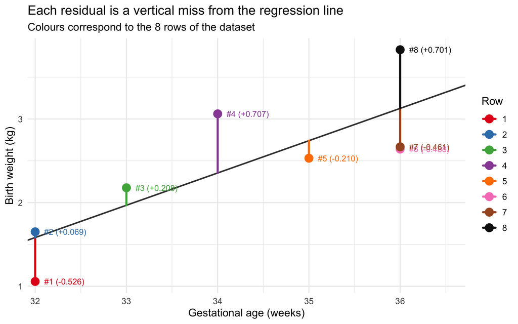

```r
plot_df <- hand_tbl %>%
  mutate(row_factor = factor(row_id, levels = 1:8))

ggplot(plot_df, aes(x = weeks, y = weight_kg, color = row_factor)) +
  geom_abline(intercept = b0, slope = b1,
              color = "grey25", linewidth = 0.8) +
  geom_segment(aes(xend = weeks, yend = y_hat),
               linewidth = 1.1, lineend = "round") +
  geom_point(size = 4) +
  geom_text(aes(label = paste0("#", row_id, " (", sprintf("%+.3f", residual), ")")),
            nudge_x = 0.1, hjust = 0, size = 3.2, show.legend = FALSE) +
  scale_color_manual(values = row_colors, name = "Row") +
  scale_x_continuous(expand = expansion(mult = c(0.02, 0.15))) +
  labs(
    title    = "Each residual is a vertical miss from the regression line",
    subtitle = "Colours correspond to the 8 rows of the dataset",
    x = "Gestational age (weeks)",
    y = "Birth weight (kg)"
  ) +
  theme_minimal(base_size = 12)
```

# 5. Sorting the residuals

The five-number summary starts by sorting the residuals from smallest to largest.

```r
sorted_tbl <- hand_tbl %>%
  arrange(residual) %>%
  mutate(sort_position = row_number()) %>%
  select(sort_position, row_id, weeks, weight_kg, y_hat, residual)

sorted_tbl
```

| sort_position | row_id | weeks | weight_kg | y_hat | residual |
| --- | --- | --- | --- | --- | --- |
| 1 | 1 | 32 | 1.057 | 1.583 | -0.5256 |
| 2 | 6 | 36 | 2.640 | 3.128 | -0.4878 |
| 3 | 7 | 36 | 2.667 | 3.128 | -0.4606 |
| 4 | 5 | 35 | 2.531 | 2.741 | -0.2104 |
| 5 | 2 | 32 | 1.651 | 1.583 | 0.0686 |
| 6 | 3 | 33 | 2.177 | 1.969 | 0.2084 |
| 7 | 8 | 36 | 3.828 | 3.128 | 0.7006 |
| 8 | 4 | 34 | 3.062 | 2.355 | 0.7066 |

Even after sorting, each residual still **remembers its original row number (and its colour)**. That’s how we can track a point from the regression plot to its place in the sorted list.

A compact view of the sorted residuals on a number line — from here on we drop the `#n` labels and the legend; the **colour** is enough to track each observation.

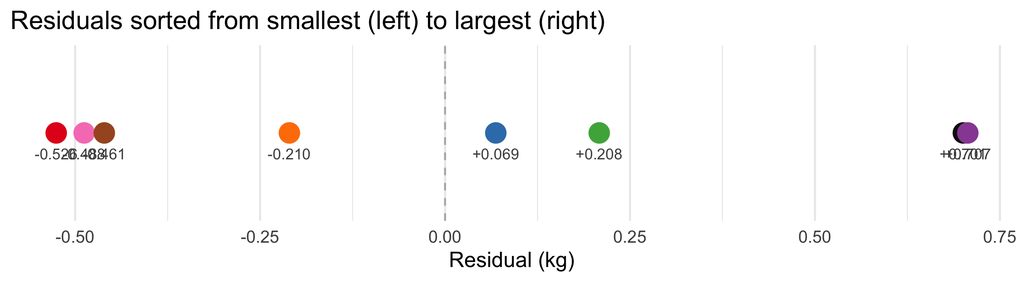

```r
sorted_plot_df <- sorted_tbl %>%
  mutate(row_factor = factor(row_id, levels = 1:8))

ggplot(sorted_plot_df, aes(x = residual, y = 0, color = row_factor)) +
  geom_vline(xintercept = 0, color = "grey70", linetype = "dashed") +
  geom_point(size = 5) +
  geom_text(aes(label = sprintf("%+.3f", residual)),
            vjust = 2.4, size = 3.0, color = "grey30", show.legend = FALSE) +
  scale_color_manual(values = row_colors, guide = "none") +
  scale_y_continuous(limits = c(-0.4, 0.4), breaks = NULL) +
  labs(x = "Residual (kg)", y = NULL,
       title = "Residuals sorted from smallest (left) to largest (right)") +
  theme_minimal(base_size = 12)
```

# 6. Where the five-number summary comes from (interpolation)

With $n = 8$ observations, R places the quartiles using the formula

$$h \;=\; (n - 1)\,p + 1$$

and then **linearly interpolates** between the two residuals on either side of position $h$. Working it out for our data:

| landmark | $p$ | $h = (8-1)p + 1$ | between positions | weight on upper |
| --- | --- | --- | --- | --- |
| Min | 0 | 1 | — (exactly row 1) | — |
| 1Q | 0.25 | **2.75** | 2 and 3 | 0.75 |
| Median | 0.50 | **4.50** | 4 and 5 | 0.50 |
| 3Q | 0.75 | **6.25** | 6 and 7 | 0.25 |
| Max | 1 | 8 | — (exactly row 8) | — |

So none of the three quartiles hits a real residual — each is a weighted average of its two neighbours. Let’s verify all three by hand.

```r
r <- sorted_tbl$residual   # already sorted smallest to largest

q1_hand <- r[2] + 0.75 * (r[3] - r[2])
md_hand <- r[4] + 0.50 * (r[5] - r[4])
q3_hand <- r[6] + 0.25 * (r[7] - r[6])

cat("--- 1Q  (h = 2.75, weight 0.75 on position 3) ---\n")
## --- 1Q  (h = 2.75, weight 0.75 on position 3) ---
cat(sprintf("x_(2) = %.4f   (row %d)\n", r[2], sorted_tbl$row_id[2]))
## x_(2) = -0.4878   (row 6)
cat(sprintf("x_(3) = %.4f   (row %d)\n", r[3], sorted_tbl$row_id[3]))
## x_(3) = -0.4606   (row 7)
cat(sprintf("1Q  = x_(2) + 0.75 * (x_(3) - x_(2))\n"))
## 1Q  = x_(2) + 0.75 * (x_(3) - x_(2))
cat(sprintf("    = %.4f + 0.75 * (%.4f - %.4f)\n", r[2], r[3], r[2]))
##     = -0.4878 + 0.75 * (-0.4606 - -0.4878)
cat(sprintf("    = %.4f\n\n", q1_hand))
##     = -0.4674

cat("--- Median  (h = 4.5, weight 0.50 on position 5) ---\n")
## --- Median  (h = 4.5, weight 0.50 on position 5) ---
cat(sprintf("x_(4) = %.4f   (row %d)\n", r[4], sorted_tbl$row_id[4]))
## x_(4) = -0.2104   (row 5)
cat(sprintf("x_(5) = %.4f   (row %d)\n", r[5], sorted_tbl$row_id[5]))
## x_(5) = 0.0686   (row 2)
cat(sprintf("Med = x_(4) + 0.50 * (x_(5) - x_(4))\n"))
## Med = x_(4) + 0.50 * (x_(5) - x_(4))
cat(sprintf("    = %.4f + 0.50 * (%.4f - %.4f)\n", r[4], r[5], r[4]))
##     = -0.2104 + 0.50 * (0.0686 - -0.2104)
cat(sprintf("    = %.4f\n\n", md_hand))
##     = -0.0709

cat("--- 3Q  (h = 6.25, weight 0.25 on position 7) ---\n")
## --- 3Q  (h = 6.25, weight 0.25 on position 7) ---
cat(sprintf("x_(6) = %.4f   (row %d)\n", r[6], sorted_tbl$row_id[6]))
## x_(6) = 0.2084   (row 3)
cat(sprintf("x_(7) = %.4f   (row %d)\n", r[7], sorted_tbl$row_id[7]))
## x_(7) = 0.7006   (row 8)
cat(sprintf("3Q  = x_(6) + 0.25 * (x_(7) - x_(6))\n"))
## 3Q  = x_(6) + 0.25 * (x_(7) - x_(6))
cat(sprintf("    = %.4f + 0.25 * (%.4f - %.4f)\n", r[6], r[7], r[6]))
##     = 0.2084 + 0.25 * (0.7006 - 0.2084)
cat(sprintf("    = %.4f\n\n", q3_hand))
##     = 0.3315

cat("--- Checks against R ---\n")
## --- Checks against R ---
print(round(quantile(resid(model)), 4))
##      0%     25%     50%     75%    100%
## -0.5256 -0.4674 -0.0709  0.3315  0.7067
cat(sprintf("\nHand 1Q  = %.4f   vs   R 1Q  = %.4f\n",
            q1_hand, quantile(resid(model), 0.25)))
##
## Hand 1Q  = -0.4674   vs   R 1Q  = -0.4674
cat(sprintf("Hand Med = %.4f   vs   R Med = %.4f\n",
            md_hand, quantile(resid(model), 0.50)))
## Hand Med = -0.0709   vs   R Med = -0.0709
cat(sprintf("Hand 3Q  = %.4f   vs   R 3Q  = %.4f\n",
            q3_hand, quantile(resid(model), 0.75)))
## Hand 3Q  = 0.3315   vs   R 3Q  = 0.3315
```

All three agree exactly with R’s own output.

Visually, the three interpolated quartiles are points that sit **between** the coloured residuals:

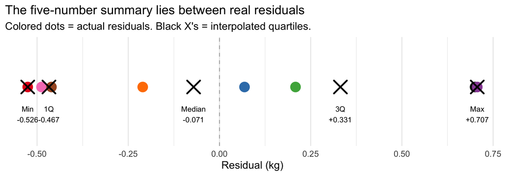

```r
q_df <- tibble(
  landmark = c("Min", "1Q", "Median", "3Q", "Max"),
  value    = c(min(r), q1_hand, md_hand, q3_hand, max(r))
)

ggplot() +
  geom_vline(xintercept = 0, color = "grey70", linetype = "dashed") +
  geom_point(
    data = sorted_plot_df,
    aes(x = residual, y = 0, color = row_factor), size = 5
  ) +
  geom_point(
    data = q_df,
    aes(x = value, y = 0),
    shape = 4, size = 6, stroke = 1.4, color = "black"
  ) +
  geom_text(
    data = q_df,
    aes(x = value, y = 0, label = paste0(landmark, "\n", sprintf("%+.3f", value))),
    vjust = 2.2, size = 3.0
  ) +
  scale_color_manual(values = row_colors, guide = "none") +
  scale_y_continuous(limits = c(-0.6, 0.5), breaks = NULL) +
  labs(x = "Residual (kg)", y = NULL,
       title = "The five-number summary lies between real residuals",
       subtitle = "Colored dots = actual residuals. Black X's = interpolated quartiles.") +
  theme_minimal(base_size = 12)
```

### Summary of section 6

- For $n = 8$ we have 8 actual residuals but only 2 of the five summary numbers (Min and Max) coincide with real residuals.
- The other three — 1Q, Median, 3Q — are **weighted averages** of two adjacent sorted residuals.
- The weights come from the formula $h = (n - 1)p + 1$ — the fractional part of $h$ tells you how much of the upper neighbour to mix in.

Slide-generator hooks:

```
## SLIDE_DATA::N=8
## SLIDE_DATA::B0=-10.78
## SLIDE_DATA::B1=0.3863
## SLIDE_DATA::WEEKS=32,32,33,34,35,36,36,36
## SLIDE_DATA::WEIGHTS=1.057,1.651,2.177,3.062,2.531,2.64,2.667,3.828
## SLIDE_DATA::Y_HAT=1.5825,1.5825,1.9688,2.3551,2.7414,3.1277,3.1277,3.1277
## SLIDE_DATA::RESIDUALS_ORIG_ORDER=-0.5256,0.0686,0.2084,0.7066,-0.2104,-0.4878,-0.4606,0.7006
## SLIDE_DATA::RESIDUALS_SORTED=-0.5256,-0.4878,-0.4606,-0.2104,0.0686,0.2084,0.7006,0.7066
## SLIDE_DATA::SORTED_ROW_IDS=1,6,7,5,2,3,8,4
## SLIDE_DATA::MIN=-0.5256
## SLIDE_DATA::Q1=-0.4674
## SLIDE_DATA::MEDIAN=-0.0709
## SLIDE_DATA::Q3=0.3315
## SLIDE_DATA::MAX=0.7066
```

# 7. Residual standard error: “how off are we, on average?”

Just under the coefficients, R prints a line of the form:

```
Residual standard error: <some number> on <n-2> degrees of freedom
```

The **residual standard error (RSE)** is trying to answer a very natural question:

> On average, how far off is the line from the actual points?

It’s the regression cousin of “average error.” But the obvious ways to compute that “average miss” all fail for interesting reasons. Let’s walk through each one before landing on the recipe R actually uses.

## 7.1 Naive attempt #1 — just average the residuals

The most natural thing to try is: sum up all the residuals, divide by $n$, call that the typical miss.

```r
mean_residual <- mean(hand_tbl$residual)
cat(sprintf("Mean of the %d residuals = %.6f kg\n",
            nrow(hand_tbl), mean_residual))
## Mean of the 8 residuals = -0.000025 kg
```

Zero (up to rounding). That’s not a coincidence and it’s not about this specific dataset — it’s a **mathematical guarantee**. Ordinary least squares picks the intercept and slope precisely so that the positive misses cancel the negative misses. No matter what data you fit, you always get this result. A quantity that’s identical for every regression can’t possibly describe the quality of any specific regression.

Visually:

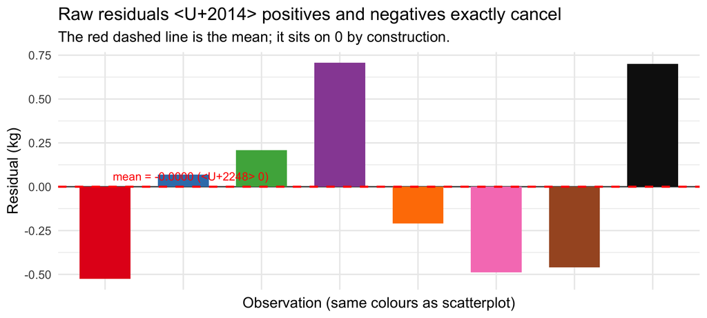

```r
naive1_df <- hand_tbl %>%
  mutate(row_factor = factor(row_id, levels = 1:8))

ggplot(naive1_df, aes(x = row_factor, y = residual, fill = row_factor)) +
  geom_hline(yintercept = 0, color = "grey30") +
  geom_col(width = 0.65) +
  geom_hline(yintercept = mean(naive1_df$residual),
             color = "red", linetype = "dashed", linewidth = 0.8) +
  annotate("text", x = 1.1, y = 0.06,
           label = sprintf("mean = %.4f (≈ 0)", mean(naive1_df$residual)),
           color = "red", hjust = 0, size = 3.3) +
  scale_fill_manual(values = row_colors, guide = "none") +
  scale_x_discrete(labels = NULL) +
  labs(x = "Observation (same colours as scatterplot)",
       y = "Residual (kg)",
       title = "Raw residuals — positives and negatives exactly cancel",
       subtitle = "The red dashed line is the mean; it sits on 0 by construction.") +
  theme_minimal(base_size = 12) +
  theme(axis.ticks.x = element_blank())
```

## 7.2 Naive attempt #2 — average the absolute values

The reason attempt #1 failed is sign. So fix the sign first by taking absolute values, *then* average. That gives the **mean absolute deviation (MAD)**:

```r
mad_naive <- mean(abs(hand_tbl$residual))
cat(sprintf("Mean absolute residual  = %.4f kg\n", mad_naive))
## Mean absolute residual  = 0.4211 kg
```

That’s a perfectly reasonable “typical miss” number, and intuitively it says: “on any given baby the line is off by about 0.42 kg.”

**Visual/algebraic reason.** Look at the two candidate “distance from zero” functions $f(x) = |x|$ and $g(x) = x^2$:

[figure not shown]

```r
curves_df <- tibble(
  x    = seq(-1, 1, length.out = 401),
  abs  = abs(x),
  sq   = x^2
) %>%
  pivot_longer(c(abs, sq), names_to = "fun", values_to = "y") %>%
  mutate(fun = recode(fun,
    abs = "y = |x|   (absolute value)",
    sq  = "y = x^2  (squared)"
  ))

ggplot(curves_df, aes(x = x, y = y)) +
  geom_line(linewidth = 1.1, color = "#377EB8") +
  geom_vline(xintercept = 0, color = "grey70", linetype = "dashed") +
  facet_wrap(~ fun, nrow = 1) +
  labs(title = "Why statisticians square instead of taking absolute value",
       subtitle = "Left: sharp corner at 0, derivative jumps. Right: perfectly smooth.",
       x = "x (a residual)", y = "penalty") +
  theme_minimal(base_size = 12) +
  theme(strip.text = element_text(face = "bold"))
```

**Why that matters.** When we pick the “best” intercept and slope for a regression, we set up a calculus problem: find the values that *minimise* the total penalty across all residuals. Calculus wants smooth functions because you solve those problems by taking derivatives and setting them to zero. With $|x|$:

- No clean derivative at zero, so no single tidy equation to solve.
- No closed-form slope/intercept — you need an iterative algorithm.
- No clean link to the normal distribution, so confidence intervals, $p$-values and $R^2$ all get messier.

With $x^2$, everything turns into a simple linear system, and the whole classical theory of regression — standard errors, $t$-tests, $F$-statistics, the lot — falls out of that one algebraic convenience.

MAD is still a perfectly valid measure of error (robust regression uses it on purpose), but for the *standard* regression R prints, squared residuals win.

## 7.3 The actual recipe — square, average, square-root

So the winning strategy is:

1. **Square each residual.** Positives and negatives now both become positives; big misses get penalised disproportionately more than small ones.
2. **Average them.** That gives a “mean squared error” — but in squared units (here, kg²), which doesn’t mean much to a human.
3. **Take the square-root.** That brings us back to the original units (kg), where the number is directly interpretable again.

And there’s one twist at step 2: we divide by $n - 2$ instead of $n$.

$$\text{RSE} \;=\; \sqrt{\frac{\sum_{i=1}^n (y_i - \hat y_i)^2}{n - 2}}$$

Why $n - 2$? Because we used the data **twice** to fit the line — once to estimate the intercept and once to estimate the slope. Those two estimates force the residuals to satisfy two constraints (they sum to zero, and they are uncorrelated with $x$). So out of $n$ residuals, only $n - 2$ are really “free” — the other two are determined by the first $n - 2$. Dividing by the number of **free** residuals (the *degrees of freedom*) gives an unbiased estimate of the true error standard deviation. With $n = 2$, the line passes through both points perfectly and $n - 2 = 0$ — there’s literally nothing left to estimate error from, which is exactly right.

### Computing RSE by hand

```r
residuals_vec <- hand_tbl$residual
n             <- length(residuals_vec)
df_resid      <- n - 2

ss_resid <- sum(residuals_vec^2)
rse_hand <- sqrt(ss_resid / df_resid)

cat(sprintf("n                         = %d\n", n))
## n                         = 8
cat(sprintf("Degrees of freedom (n-2)  = %d\n", df_resid))
## Degrees of freedom (n-2)  = 6
cat(sprintf("Sum of squared residuals  = %.4f\n", ss_resid))
## Sum of squared residuals  = 1.8089
cat(sprintf("RSE = sqrt(%.4f / %d)\n", ss_resid, df_resid))
## RSE = sqrt(1.8089 / 6)
cat(sprintf("    = sqrt(%.4f)\n", ss_resid / df_resid))
##     = sqrt(0.3015)
cat(sprintf("    = %.4f  kg\n", rse_hand))
##     = 0.5491  kg

cat(sprintf("\nR reports RSE = %.4f on %d degrees of freedom\n",
            summary(model)$sigma, summary(model)$df[2]))
##
## R reports RSE = 0.5491 on 6 degrees of freedom
```

And the table, with squared residuals alongside, for reference:

```r
rse_tbl <- hand_tbl %>%
  mutate(residual_sq = round(residual^2, 4)) %>%
  select(row_id, weeks, weight_kg, y_hat, residual, residual_sq) %>%
  bind_rows(
    tibble(
      row_id      = NA,
      weeks       = NA,
      weight_kg   = NA,
      y_hat       = NA,
      residual    = NA,
      residual_sq = round(sum(hand_tbl$residual^2), 4)
    )
  )

rse_tbl
```

| row_id | weeks | weight_kg | y_hat | residual | residual_sq |
| --- | --- | --- | --- | --- | --- |
| 1 | 32 | 1.057 | 1.583 | -0.5256 | 0.2763 |
| 2 | 32 | 1.651 | 1.583 | 0.0686 | 0.0047 |
| 3 | 33 | 2.177 | 1.969 | 0.2084 | 0.0434 |
| 4 | 34 | 3.062 | 2.355 | 0.7066 | 0.4993 |
| 5 | 35 | 2.531 | 2.741 | -0.2104 | 0.0443 |
| 6 | 36 | 2.640 | 3.128 | -0.4878 | 0.2379 |
| 7 | 36 | 2.667 | 3.128 | -0.4606 | 0.2122 |
| 8 | 36 | 3.828 | 3.128 | 0.7006 | 0.4908 |
| NA | NA | NA | NA | NA | 1.8089 |

The last row is the **sum of squared residuals (SSR)**, the engine of the whole calculation.

A bar chart of each row’s contribution to SSR (in the same colours as before) makes it clear that a few large-miss points dominate:

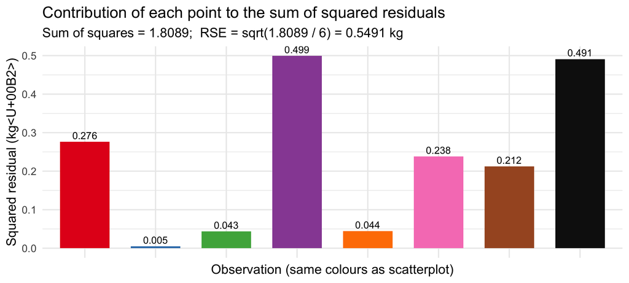

```r
rse_bar_df <- hand_tbl %>%
  mutate(row_factor = factor(row_id, levels = 1:8),
         residual_sq = residual^2)

ggplot(rse_bar_df,
       aes(x = row_factor, y = residual_sq, fill = row_factor)) +
  geom_col(width = 0.7) +
  geom_text(aes(label = sprintf("%.3f", residual_sq)),
            vjust = -0.4, size = 3.2, show.legend = FALSE) +
  scale_fill_manual(values = row_colors, guide = "none") +
  scale_x_discrete(labels = NULL) +
  labs(x = "Observation (same colours as scatterplot)",
       y = "Squared residual (kg²)",
       title = "Contribution of each point to the sum of squared residuals",
       subtitle = sprintf("Sum of squares = %.4f;  RSE = sqrt(%.4f / %d) = %.4f kg",
                          sum(rse_bar_df$residual_sq),
                          sum(rse_bar_df$residual_sq),
                          df_resid, rse_hand)) +
  theme_minimal(base_size = 12) +
  theme(axis.ticks.x = element_blank())
```

## 7.4 What RSE means in plain English

```r
mean_y <- mean(preemie_data$weight_kg)
cat(sprintf("Mean birth weight in our sample: %.2f kg\n", mean_y))
## Mean birth weight in our sample: 2.45 kg
cat(sprintf("RSE:                             %.2f kg\n", rse_hand))
## RSE:                             0.55 kg
cat(sprintf("RSE as %% of mean:                %.1f%%\n",
            100 * rse_hand / mean_y))
## RSE as % of mean:                22.4%
```

So in this toy dataset the line typically misses each actual birth weight by about 0.55 kg — roughly 22% of the average birth weight. That’s a much more honest summary of fit quality than “the mean residual is zero,” which is always true and never useful.

```
## SLIDE_DATA_RSE::SSR=1.809
## SLIDE_DATA_RSE::DF=6
## SLIDE_DATA_RSE::RSE=0.5491
## SLIDE_DATA_RSE::MEAN_Y=2.452
```

# 8. Summary to hand to the slide generator

```
## ============================================================
## KEY TAKEAWAYS
## ============================================================
## 1. A residual is (observed y) minus (predicted y) — a vertical
##    distance from a point to the fitted line.
## 2. R's 'Residuals:' row is the 5-number summary of those
##    residuals: Min, 1Q, Median, 3Q, Max.
## 3. Min and Max are always the smallest/largest actual residual.
## 4. 1Q, Median, 3Q are computed by the formula h = (n-1)*p + 1
##    and LINEAR INTERPOLATION between the two sorted residuals on
##    either side of position h. Only when h happens to be a whole
##    number does a quartile coincide with a real residual.
## 5. Residual standard error = sqrt(SSR / (n - 2)).
##    - Squaring removes sign so misses don't cancel.
##    - Square-root restores the original units.
##    - n - 2 (not n) accounts for the two parameters already spent
##      estimating intercept and slope.
## 6. RSE answers: 'on average, how far off is the line?'
## ============================================================
```